# generalized linear mixed models: overview

Ben Bolker

## (Generalized) linear mixed models

a statistical modeling framework incorporating:

- combinations of categorical and continuous predictors,  
  and interactions
- (some) non-Normal responses  
  (e.g. binomial, Poisson, and extensions)
- (some) nonlinearity  
  (e.g. logistic, exponential, hyperbolic)
- non-independent (grouped) data  
  (can also be used to implement correlations and smooth terms)

## a small corner of the universe

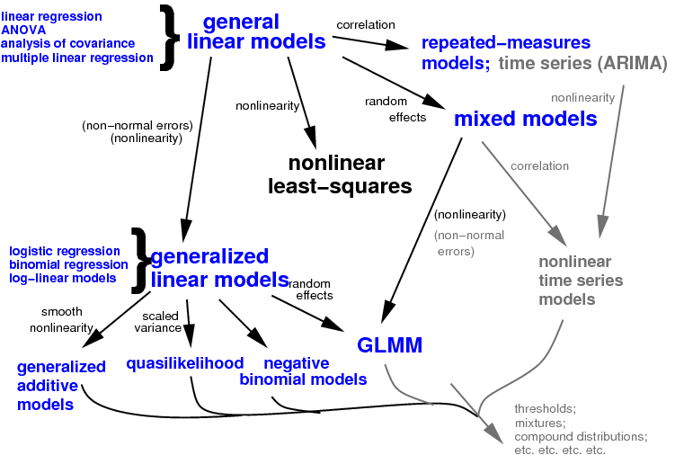

## Coral protection from seastars (*Culcita*) by symbionts<sup>1</sup>

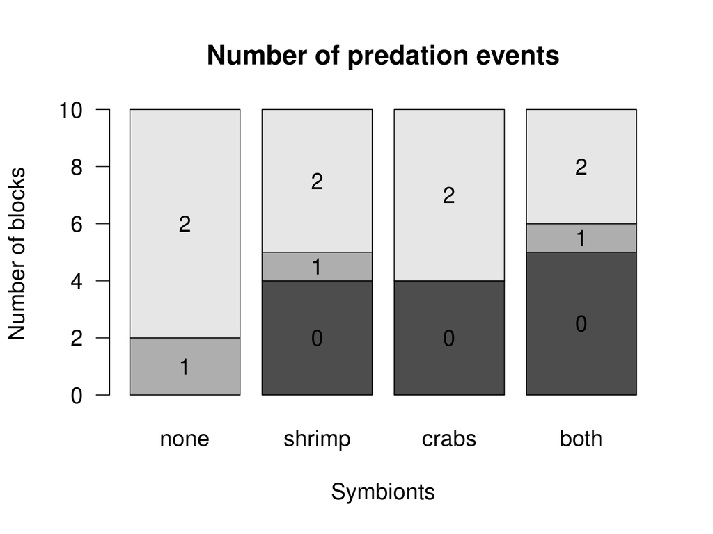

## Environmental stress: *Glycera* cell survival (D. Julian unpubl.)

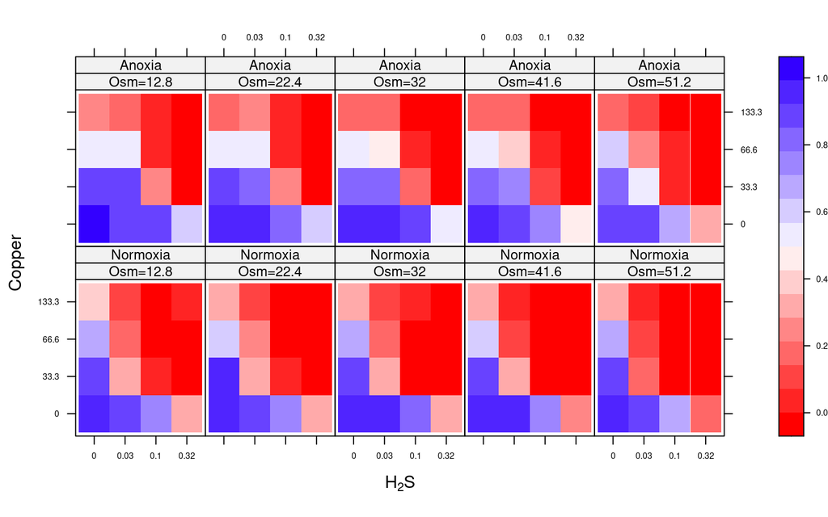

## simulated herbivory of *Arabidopsis*<sup>2</sup>

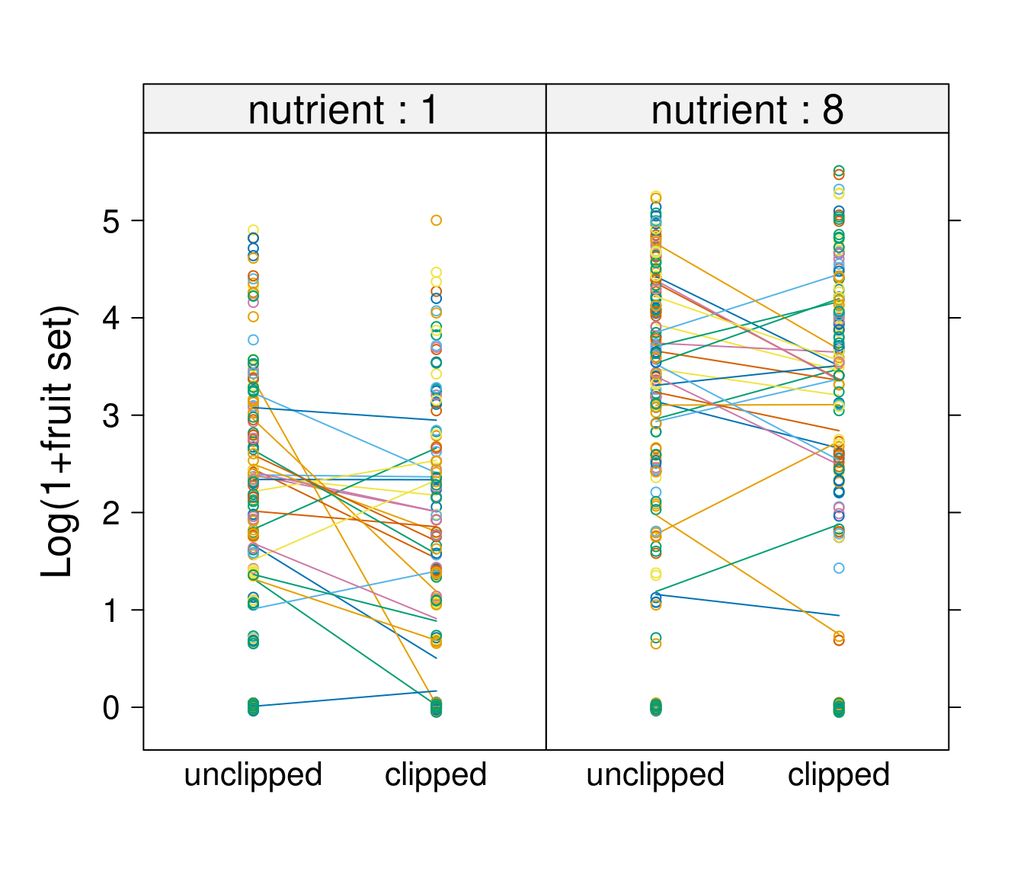

## Coral demography (J.-S. White unpubl.)

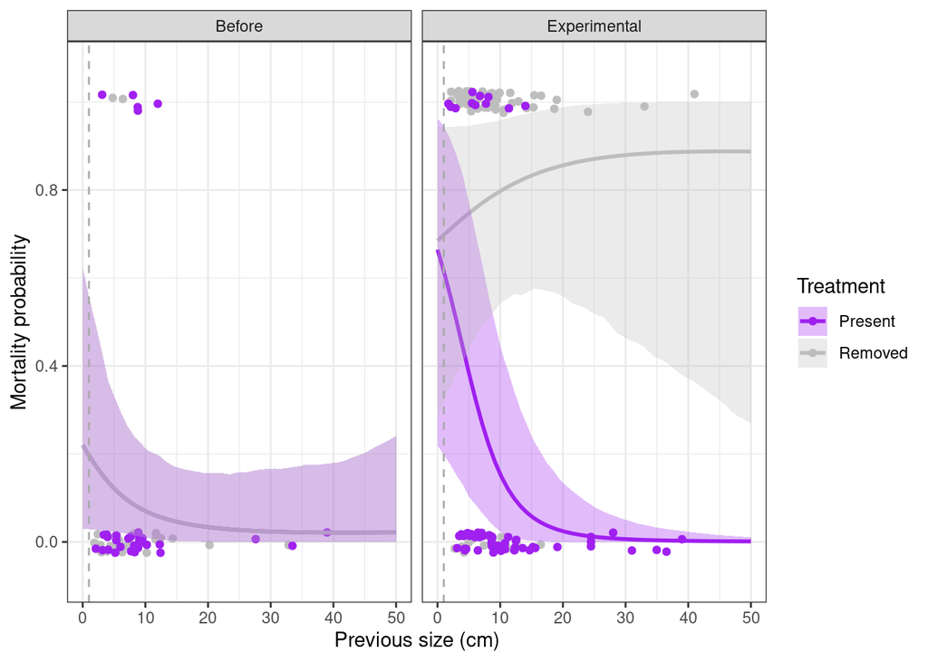

## Intercept random effects

- Could have multiple, nested levels of random effects  
  (genotype within population within region …), or *crossed* REs
- formula: `y ~ 1 + x + (1 | g)`

## Random-slopes model

$$\begin{split}
y_{ij} & = \beta_0 + \beta_1 x_{ij} + \epsilon_{0,ij} +
\epsilon_{1,j} +
\epsilon_{2,j} x_{ij} \\
& = (\beta_0 + \epsilon_{1,j}) + (\beta_1 + \epsilon_{2,j}) x_{ij} +
\epsilon_{0,ij} \\
\epsilon_{0,ij} & \sim \textrm{Normal}(0,\sigma_0^2) \\
\{\epsilon_{1,j}, \epsilon_{2,j}\} & \sim \textrm{MVN}(0,\Sigma)
\end{split}$$

- variation in the *effect* of a treatment or covariate across groups
- estimate the correlation between the intercept and slope
- formula: `y ~ 1 + x + (1 + x | g)`

## General definition

$$\begin{split}
\underbrace{Y_i}_{\text{response}} & \sim
\overbrace{\text{Distr}}^{\substack{\text{conditional} \\
\text{distribution}}}(\underbrace{g^{-1}(\eta_i)}_{\substack{\text{inverse}
\\ \text{link} \\
\text{function}}},\underbrace{\phi}_{\substack{\text{scale} \\
\text{parameter}}}) \\
\underbrace{\boldsymbol \eta}_{\substack{\text{linear} \\
\text{predictor}}} &
=
\underbrace{\boldsymbol X \boldsymbol \beta}_{\substack{\text{fixed} \\
\text{effects}}} +
\underbrace{\boldsymbol Z \boldsymbol b}_{\substack{\text{random} \\
\text{effects}}}
\\
\underbrace{\boldsymbol b}_{\substack{\text{conditional} \\
\text{modes}}} &
\sim \text{MVN}(\boldsymbol 0, \underbrace{\Sigma(\boldsymbol
\theta)}_{\substack{\text{covariance} \\ \text{matrix}}})
\end{split}$$

- the structure of $Z$ and $\Sigma$ reflect one or more underlying categorical *grouping variables* (*clusters*, *blocks*, subjects, etc. etc.) or combinations thereof

## What are random effects?

A method for …

- accounting for correlations among observations within clusters
- compromising between  
  *complete pooling* (no among-cluster variance)  
  and *fixed effects* (large among-cluster variance)
- handling levels selected at random from a larger population
- sharing information among levels (*shrinkage estimation*)
- estimating variability among clusters
- allowing predictions for unmeasured clusters

## Random-effect myths

- clusters must always be sampled at random
- a complete sample cannot be treated as a random effect
- random effects are always a *nuisance variable*
- nothing can be said about the predictions of a random effect
- you should always use a random effect no matter how few levels you have

## Why use random effects? (inferential/philosophical)

When you:

- **do** want to
  - quantify variation among groups
  - make predictions about unobserved groups
- have (randomly) sampled clusters from a larger population
- have clusters that are **exchangeable**
- **don’t** want to
  - test hypotheses about differences between particular clusters

## Why use random effects? (practical)<sup>3,4</sup>

- want to combine information across groups
- have variation in information per cluster (number of samples or noisiness);
- have a categorical predictor that is a nuisance variable (i.e., it is not of direct interest, but should be controlled for).
- have more than 5-6 groups, or regularizing/using priors (otherwise, use fixed)

## Avoiding MM

- for *nested* designs: compute cluster means<sup>5</sup>
- use fixed effects (or *two-stage models*) when there are
  - many samples per cluster
  - few clusters

# Estimation

## Maximum likelihood estimation

- Best fit is a compromise between two components  
  (consistency of data with fixed effects and conditional modes; consistency of random effect with RE distribution)
- $\underbrace{{\cal L}(\boldsymbol \beta,\boldsymbol \theta)}_{\substack{\text{marginal} \\ \text{likelihood}}} = \int \underbrace{{\cal L}(\boldsymbol y|\beta,b)}_{\substack{\text{conditional} \\ \text{likelihood}}} \cdot {\cal L}(\boldsymbol b|\Sigma(\theta)) \, d\boldsymbol b$

## …

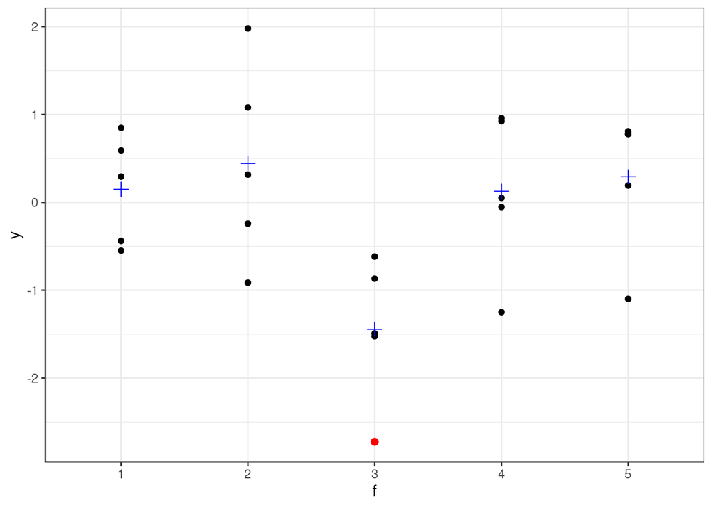

## Shrinkage: *Arabidopsis* example

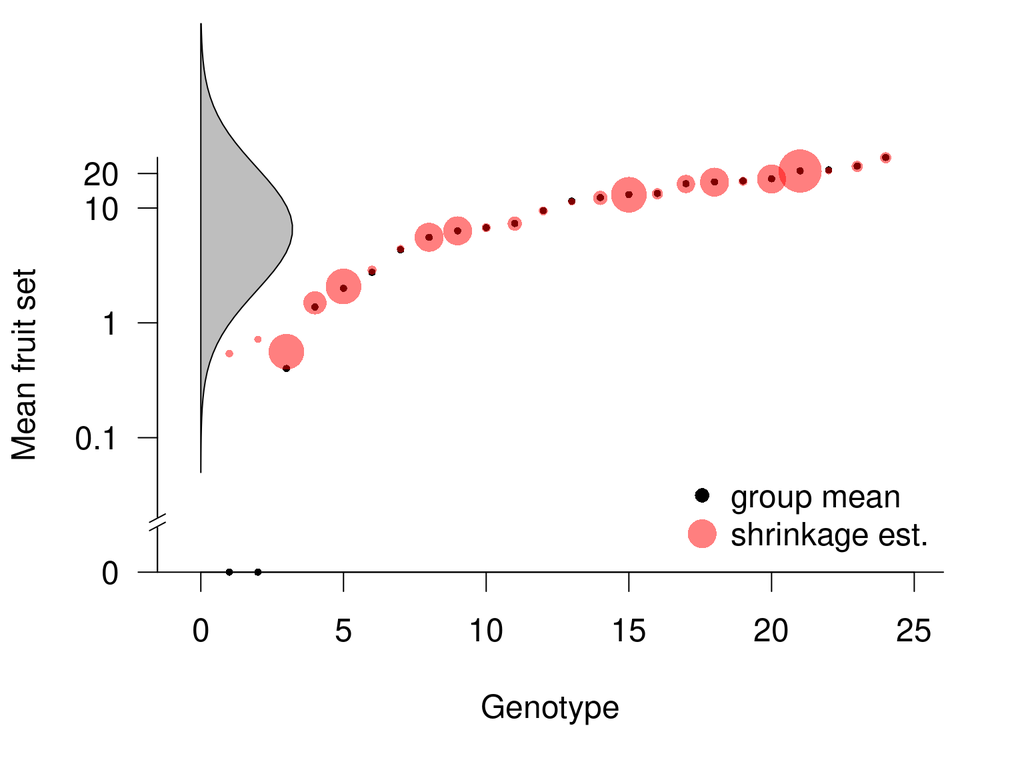

## Shrinkage in a random-slopes model

From Christophe Lalanne, see [here](https://stats.stackexchange.com/questions/51186/what-would-be-an-illustrative-picture-for-linear-mixed-models):

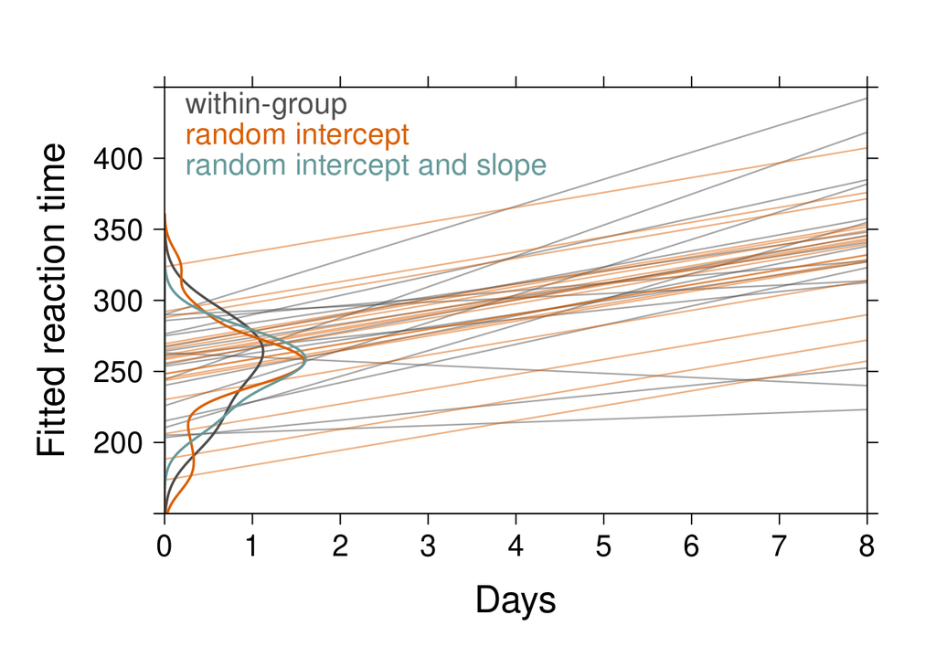

# A tiny bit about GLMs

## GLMs

- relax assumption of Gaussian conditional distribution
- classic GLMs from the *exponential (dispersion) family* (binomial, Poisson, Gamma, …)
- *link function* and *variance function*
- some packages (based on MLE) relax the exponential-family requirement (Beta, Student-$t$, Tweedie, skew-normal, …)
- still allow/use a link function

## beyond GLMs

- many other variations are possible
- zero-inflated (altered) and hurdle models
- censored data
- scale-location models (dispersion parameter gets its own model)
- predictor variable → *linear predictor* still governed by a linear model (for convenience)

# Methods

## Estimation

- we need to compute an integral
- in *linear* mixed models the integral goes away (replaced by fancy linear algebra)
- deterministic
  - various approximate integrals<sup>6</sup>:  
    penalized quasi-likelihood, Laplace, Gauss-Hermite quadrature, …<sup>7</sup>;
  - more care needed for large variance, small clusters (e.g. binary data)
  - flexibility and speed vs. accuracy
- stochastic (Monte Carlo): frequentist and Bayesian<sup>8–10</sup>. MCMC, importance sampling
  - (much) slower but flexible and accurate

## Estimation: *Culcita*<sup>1</sup>

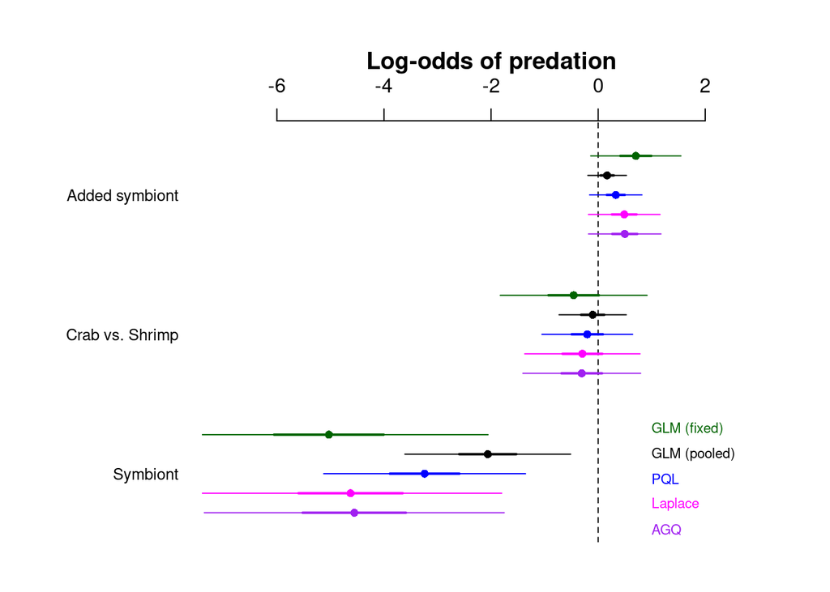

## What is the maximal model?

- Which effects vary *within* which groups?
- If effects don’t vary within groups, then we *can’t* estimate among-group variation in the effect
  - convenient
  - maybe less powerful
- e.g. female rats exposed to different doses of radiation, multiple pups per mother, multiple measurements per pup (labeled by time). Maximal model … ?
- Maximal model is often impractical/unfeasible
  - *Culcita* (coral-reef) example: randomized-block design, so each treatment (none/crabs/shrimp/both) is repeated in every block; thus `(treat|block)` is maximal
  - CBPP data: each herd is measured in every period, so in principle we could use `(period|herd)`, not just `(1|herd)`

# Inference

## Wald tests/CIs

- typical results of `summary()`
- symmetric CIs
- assumes log-likelihood surface is *quadratic*
- exact for linear models: approximate for (G)LMMs
- fast
- approximation sometimes awful (*complete separation*)
- “denominator degrees of freedom” issues
  - e.g. Kenward-Roger correction<sup>11</sup>

## Likelihood ratio tests/profile CIs

- better than Wald, but still asymptotic
- for hypothesis tests, fit & compare full and nested models (`anova()`, `drop1()`)
- for CIs, compute *profile confidence intervals* (slow)

## Nonparametric bootstrap

- Bootstrapping: slow, but gold standard for frequentist models
- Need to respect structure when resampling
  - Residual bootstrapping for LMMs
  - Nested resampling where possible
- `lmeresampler` package

## Parametric bootstrap

- works for any model (including crossed-RE GLMMs)
- fit null model to data
- simulate “data” from null model
- fit null and working model, compute likelihood difference
- repeat to estimate null distribution
- assumes model correctly specified
- `bootMer()`, `pbkrtest` package

## Bayesian inference

- If we have a good sample from the posterior distribution, we get everything we want for free
- Bayesian methods are more challenging to make work, and slow
- Gibbs sampling $\to$ *Hamiltonian Monte Carlo*
- `MCMCglmm` (Gibbs), `brms` (HMC), `rstanarm` (HMC)

# Challenges & open questions

## Landscape

- frequentist: `nlme`, `lme4`, `glmmTMB`, `MixedModels.jl` (Julia)
- Bayesian: `MCMCglmm`, `rstanarm`, `brms`, `bamlss`, `INLA`
- build-your-own: `greta`, `RTMB`, `NIMBLE`, `Stan` (`rethinking` package)
- spatial: `glmmTMB`, `sdmTMB`, `spaMM`

## resources

- [Mixed models CRAN task view](https://cran.r-project.org/web/views/MixedModels.html)
- http://ms.mcmaster.ca/~bolker/misc/private/14-Fox-Chap13.pdf
- https://bbolker.github.io/mixedmodels-misc/ecostats_chap.html
- <sup>17</sup>

(code ASPROMP8)

## references

1.

McKeon, C. S., Stier, A., McIlroy, S. & Bolker, B. [Multiple defender effects: Synergistic coral defense by mutualist crustaceans](https://doi.org/10.1007/s00442-012-2275-2). *Oecologia* **169**, 1095–1103 (2012).

2.

Banta, J. A., Stevens, M. H. H. & Pigliucci, M. [A comprehensive test of the ’limiting resources’ framework applied to plant tolerance to apical meristem damage](https://doi.org/10.1111/j.1600-0706.2009.17726.x). *Oikos* **119**, 359–369 (2010).

3.

Crawley, M. J. *Statistical Computing: An Introduction to Data Analysis Using S-PLUS*. (John Wiley & Sons, 2002).

4.

Gelman, A. [Analysis of variance: Why it is more important than ever](https://doi.org/doi:10.1214/009053604000001048). *Annals of Statistics* **33**, 1–53 (2005).

5.

Murtaugh, P. A. [Simplicity and complexity in ecological data analysis](http://www.esajournals.org/doi/abs/10.1890/0012-9658%282007%2988%5B56%3ASACIED%5D2.0.CO%3B2). *Ecology* **88**, 56–62 (2007).

6.

Breslow, N. E. Whither PQL? in *Proceedings of the second Seattle symposium in biostatistics: Analysis of correlated data* (eds. Lin, D. Y. & Heagerty, P. J.) 1–22 (Springer, 2004).

7.

Biswas, K. [Performances of different estimation methods for generalized linear mixed models](https://macsphere.mcmaster.ca/bitstream/11375/17272/2/M.Sc_Thesis_final_Keya_Biswas.pdf). (McMaster University, 2015).

8.

Booth, J. G. & Hobert, J. P. [Maximizing generalized linear mixed model likelihoods with an automated Monte Carlo EM algorithm](https://doi.org/10.1111/1467-9868.00176). *Journal of the Royal Statistical Society. Series B* **61**, 265–285 (1999).

9.

Sung, Y. J. & Geyer, C. J. [Monte Carlo likelihood inference for missing data models](https://doi.org/10.1214/009053606000001389). *The Annals of Statistics* **35**, 990–1011 (2007).

10.

Ponciano, J. M., Taper, M. L., Dennis, B. & Lele, S. R. [Hierarchical models in ecology: Confidence intervals, hypothesis testing, and model selection using data cloning](http://www.jstor.org/stable/27650990). *Ecology* **90**, 356–362 (2009).

11.

Stroup, W. W. [Rethinking the analysis of non-normal data in plant and soil science](https://doi.org/10.2134/agronj2013.0342). *Agronomy Journal* **106**, 1–17 (2014).

12.

Barr, D. J., Levy, R., Scheepers, C. & Tily, H. J. [Random effects structure for confirmatory hypothesis testing: Keep it maximal](https://doi.org/10.1016/j.jml.2012.11.001). *Journal of Memory and Language* **68**, 255–278 (2013).

13.

Bates, D., Kliegl, R., Vasishth, S. & Baayen, H. [Parsimonious Mixed Models](http://arxiv.org/abs/1506.04967). *arXiv:1506.04967 [stat]* (2015).

14.

Ives, A. R. & Zhu, J. [Statistics for correlated data: Phylogenies, space, and time](http://www.esajournals.org/doi/pdf/10.1890/04-0702). *Ecological Applications* **16**, 20–32 (2006).

15.

Rue, H., Martino, S. & Chopin, N. Gaussian models using integrated nested Laplace approximations (with discussion). *Journal of the Royal Statistical Society, Series B* **71**, 319–392 (2009).

16.

Rousset, F. & Ferdy, J.-B. Testing environmental and genetic effects in the presence of spatial autocorrelation. *Ecography* no–no (2014) doi:10.1111/ecog.00566.

17.

Bolker, B. M. Linear and generalized linear mixed models. in *Ecological statistics: Contemporary theory and application* (eds. Fox, G. A., Negrete-Yankelevich, S. & Sosa, V. J.) (Oxford University Press, 2015).